# Financial Stress Early Warning System

February 20, 2019

## Summary

- Businesses, governments, and non-governmental organizations want to know when individuals are facing financial stress.
- Financial stress means:
  - Businesses: Lower sales, higher defaults
  - Governments: Pressure on social services, policy needs
  - Non-Governmental Organizations: Supplemental assistance, advocacy
- Major financial stress indicators are backward looking between a week and a quarter.
- Can Google Trends–acting as a real-time indicator–be used to "nowcast" financial stress?

## Google Trends vs. New Unemployment Insurance Filings

[figure not shown]

## Improving the Model

- Goolge Trends can predict new unemployment filings with high-degree of accuracy using a basic model.
  - Model is tslm with search terms–unemployment insurance + food stamps + temp agencies + resume–and continuing unemployiment claims
  - Also adjusts for trend + seasonality
- MAPE: 3.2%
  - 77% reduction in MAPE compared just to "unemployment insurance"
  - 8% reduction in MAPE compared to unemployment insurance + trend + seasonality

## Fitted Model vs. Actual Filings

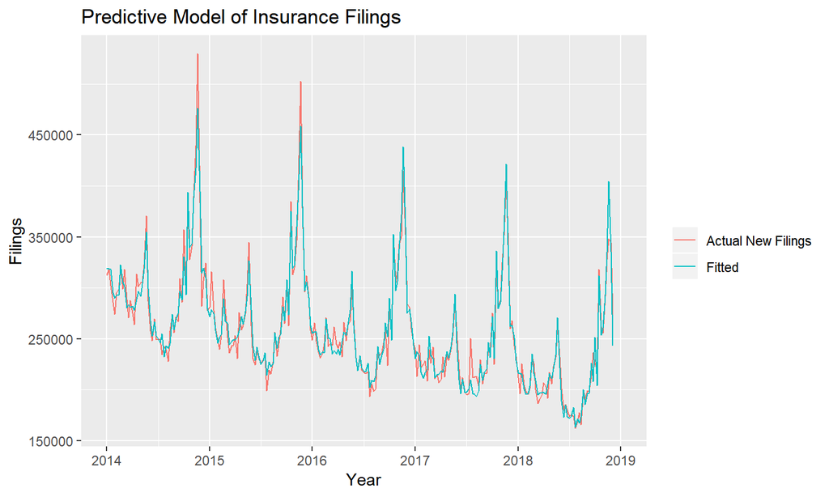